# Convolutional Neural Networks

## Project: Write an Algorithm for a Dog Identification App

## Importing The Dataset

```python
# extracting zip files

import zipfile

#with zipfile.ZipFile("dogImages.zip","r") as zip_ref:
 #   zip_ref.extractall("dogImages")

with zipfile.ZipFile("lfw.zip","r") as zip_ref:
    zip_ref.extractall("lfw")
```

```python
import numpy as np
from glob import glob

# load filenames for human and dog images
human_files = np.array(glob("lfw/lfw/*/*"))
dog_files = np.array(glob("dogImages/dogImages/*/*/*"))

# print number of images in each dataset
print('There are %d total human images.' % len(human_files))
print('There are %d total dog images.' % len(dog_files))
```

```
There are 13233 total human images.
There are 8351 total dog images.
```

## Step 1: Detect Humans

In this section, we use OpenCV's implementation of [Haar feature-based cascade classifiers](http://docs.opencv.org/trunk/d7/d8b/tutorial_py_face_detection.html) to detect human faces in images.

OpenCV provides many pre-trained face detectors, stored as XML files on [github](https://github.com/opencv/opencv/tree/master/data/haarcascades). We have downloaded one of these detectors and stored it in the `haarcascades` directory. In the next code cell, we demonstrate how to use this detector to find human faces in a sample image.

```python
human_files[0]
```

```
'lfw/lfw/Richard_Barry/Richard_Barry_0001.jpg'
```

```
Number of faces detected: 2
```

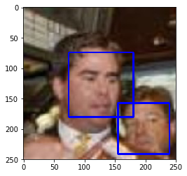

```python
import cv2
import matplotlib.pyplot as plt
%matplotlib inline

# extract pre-trained face detector
face_cascade = cv2.CascadeClassifier('haarcascades/haarcascade_frontalface_alt.xml')

# load color (BGR) image
img = cv2.imread(human_files[0])
# convert BGR image to grayscale
gray = cv2.cvtColor(img, cv2.COLOR_BGR2GRAY)

# find faces in image
faces = face_cascade.detectMultiScale(gray)

# print number of faces detected in the image
print('Number of faces detected:', len(faces))

# get bounding box for each detected face
for (x,y,w,h) in faces:
    # add bounding box to color image
    cv2.rectangle(img,(x,y),(x+w,y+h),(255,0,0),2)

# convert BGR image to RGB for plotting
cv_rgb = cv2.cvtColor(img, cv2.COLOR_BGR2RGB)

# display the image, along with bounding box
plt.imshow(cv_rgb)
plt.show()
```

Before using any of the face detectors, it is standard procedure to convert the images to grayscale. The `detectMultiScale` function executes the classifier stored in `face_cascade` and takes the grayscale image as a parameter.

In the above code, `faces` is a numpy array of detected faces, where each row corresponds to a detected face. Each detected face is a 1D array with four entries that specifies the bounding box of the detected face. The first two entries in the array (extracted in the above code as `x` and `y`) specify the horizontal and vertical positions of the top left corner of the bounding box. The last two entries in the array (extracted here as `w` and `h`) specify the width and height of the box.

### Write a Human Face Detector

We can use this procedure to write a function that returns `True` if a human face is detected in an image and `False` otherwise. This function, aptly named `face_detector`, takes a string-valued file path to an image as input and appears in the code block below.

```python
# returns "True" if face is detected in image stored at img_path
def face_detector(img_path):
    img = cv2.imread(img_path)
    gray = cv2.cvtColor(img, cv2.COLOR_BGR2GRAY)
    faces = face_cascade.detectMultiScale(gray)
    return len(faces) > 0
```

### (IMPLEMENTATION) Assess the Human Face Detector

**Questions:**

- What percentage of the first 100 images in `human_files` have a detected human face?
- What percentage of the first 100 images in `dog_files` have a detected human face?

Ideally, we would like 100% of human images with a detected face and 0% of dog images with a detected face. However, we will see that our algorithm falls short of this goal, but still gives acceptable performance. We extract the file paths for the first 100 images from each of the datasets and store them in the numpy arrays `human_files_short` and `dog_files_short`.

```python
from tqdm import tqdm

human_files_short = human_files[:100]
dog_files_short = dog_files[:100]

#-#-# Do NOT modify the code above this line. #-#-#
human_in_human = np.empty(0)
human_in_dog = np.empty(0)
for i in range(len(human_files_short)):
    if (face_detector(human_files_short[i]) == True):
        human_in_human = np.append(human_in_human, 1)
    else:
        human_in_human = np.append(human_in_human, 0)

    if (face_detector(dog_files_short[i])==True):
        human_in_dog = np.append(human_in_dog, 1)
    else:
        human_in_dog = np.append(human_in_dog, 0)

## TODO: Test the performance of the face_detector algorithm
## on the images in human_files_short and dog_files_short.
human_in_human.mean(), human_in_dog.mean()
```

```
(0.96, 0.18)
```

As we predicted, the algorithm detected humans with 96% accuracy, and suggested that 18% of the dog images are related to humans.

## Step 2: Detect Dogs

In this section, we use a [pre-trained model](http://pytorch.org/docs/master/torchvision/models.html) to detect dogs in images.

### Obtain Pre-trained VGG-16 Model

The code cell below downloads the VGG-16 model, along with weights that have been trained on [ImageNet](http://www.image-net.org/), a very large, very popular dataset used for image classification and other vision tasks. ImageNet contains over 10 million URLs, each linking to an image containing an object from one of [1000 categories](https://gist.github.com/yrevar/942d3a0ac09ec9e5eb3a).

```python
import torch
import torchvision.models as models

# define VGG16 model
VGG16 = models.vgg16(pretrained=True)

# check if CUDA is available
use_cuda = torch.cuda.is_available()

# move model to GPU if CUDA is available
if use_cuda:
    VGG16 = VGG16.to('cuda')
```

```
Downloading: "https://download.pytorch.org/models/vgg16-397923af.pth" to /root/.torch/models/vgg16-397923af.pth
```

Given an image, this pre-trained VGG-16 model returns a prediction (derived from the 1000 possible categories in ImageNet) for the object that is contained in the image.

### (IMPLEMENTATION) Making Predictions with a Pre-trained Model

In the next code cell, we wrote a function that accepts a path to an image (such as `'dogImages/train/001.Affenpinscher/Affenpinscher_00001.jpg'`) as input and returns the index corresponding to the ImageNet class that is predicted by the pre-trained VGG-16 model. The output should always be an integer between 0 and 999, inclusive.

```python
from PIL import Image
import torchvision.transforms as transforms

transform = transforms.Compose([
    transforms.Resize(256),
    transforms.CenterCrop(224),
    transforms.ToTensor(),
    transforms.Normalize(
    mean=[0.485, 0.456, 0.406],
    std=[0.229, 0.224, 0.225])])


# Set PIL to be tolerant of image files that are truncated.
from PIL import ImageFile
ImageFile.LOAD_TRUNCATED_IMAGES = True

def VGG16_predict(img_path):
    '''
    Use pre-trained VGG-16 model to obtain index corresponding to
    predicted ImageNet class for image at specified path

    Args:
        img_path: path to an image

    Returns:
        Index corresponding to VGG-16 model's prediction
    '''

    img = Image.open(img_path)
    img_t = transform(img)
    if use_cuda:
        img_t = img_t.cuda()
    batch_t = torch.unsqueeze(img_t,0)
    VGG16.eval()
    prediction = VGG16(batch_t)
    highest, index = torch.max(prediction, 1)

    return index # predicted class index
```

### (IMPLEMENTATION) Write a Dog Detector

While looking at the [dictionary](https://gist.github.com/yrevar/942d3a0ac09ec9e5eb3a), we notice that the categories corresponding to dogs appear in an uninterrupted sequence and correspond to dictionary keys 151-268, inclusive, to include all categories from `'Chihuahua'` to `'Mexican hairless'`. Thus, in order to check to see if an image is predicted to contain a dog by the pre-trained VGG-16 model, we need only to check if the pre-trained model predicts an index between 151 and 268 (inclusive).

We use these ideas to complete the `dog_detector` function below, which returns `True` if a dog is detected in an image (and `False` if not).

```python
### returns "True" if a dog is detected in the image stored at img_path

import torch.nn.functional as F

def dog_detector(img_path):
    idx = VGG16_predict(img_path)
    return 151 <= idx <= 268
```

### (IMPLEMENTATION) Assess the Dog Detector

**Questions:**

- What percentage of the images in `human_files_short` have a detected dog?
- What percentage of the images in `dog_files_short` have a detected dog?

```python
### TODO: Test the performance of the dog_detector function
### on the images in human_files_short and dog_files_short.

dog_in_dog = np.empty(0)
dog_in_human = np.empty(0)
for i in range(len(human_files_short)):
    if (dog_detector(human_files_short[i]) == True):
        dog_in_human = np.append(dog_in_human, 1)
    else:
        dog_in_human = np.append(dog_in_human, 0)

    if (dog_detector(dog_files_short[i])==True):
        dog_in_dog = np.append(dog_in_dog, 1)
    else:
        dog_in_dog = np.append(dog_in_dog, 0)

## TODO: Test the performance of the face_detector algorithm
## on the images in human_files_short and dog_files_short.
dog_in_human.mean(), dog_in_dog.mean()
```

```
(0.0, 0.94)
```

## Step 3: Create a CNN to Classify Dog Breeds (from Scratch)

Now that we have functions for detecting humans and dogs in images, we need a way to predict breed from images. In this step, you will create a CNN that classifies dog breeds.

We mention that the task of assigning breed to dogs from images is considered exceptionally challenging. To see why, consider that *even a human* would have trouble distinguishing between a Brittany and a Welsh Springer Spaniel.

[output not shown]

It is not difficult to find other dog breed pairs with minimal inter-class variation (for instance, Curly-Coated Retrievers and American Water Spaniels).

[output not shown]

Likewise, recall that labradors come in yellow, chocolate, and black. The vision-based algorithm will have to conquer this high intra-class variation to determine how to classify all of these different shades as the same breed.

[output not shown]

We also mention that random chance presents an exceptionally low bar: setting aside the fact that the classes are slightly imabalanced, a random guess will provide a correct answer roughly 1 in 133 times, which corresponds to an accuracy of less than 1%.

### (IMPLEMENTATION) Specify Data Loaders for the Dog Dataset

The code cell below is to write three separate [data loaders](http://pytorch.org/docs/stable/data.html#torch.utils.data.DataLoader) for the training, validation, and test datasets of dog images (located at `dogImages/train`, `dogImages/valid`, and `dogImages/test`, respectively).

```python
import os
import torch
from torchvision import datasets
import torchvision.transforms as transforms

### TODO: Write data loaders for training, validation, and test sets
## Specify appropriate transforms, and batch_sizes


traindir = os.path.join('dogImages/dogImages', 'train')
valdir = os.path.join('dogImages/dogImages', 'valid')
testdir = os.path.join('dogImages/dogImages', 'test')



normalize = transforms.Normalize(mean=[0.485, 0.456, 0.406],
                                 std=[0.229, 0.224, 0.225])

train_loader = torch.utils.data.DataLoader(
    datasets.ImageFolder(traindir, transforms.Compose([
        transforms.RandomSizedCrop(224),
        transforms.RandomHorizontalFlip(),
        transforms.ToTensor(),
        normalize,
        ])),
    batch_size=64, shuffle=True, pin_memory=True)

val_loader = torch.utils.data.DataLoader(
datasets.ImageFolder(valdir, transforms.Compose([
            transforms.Scale(256),
            transforms.CenterCrop(224),
            transforms.ToTensor(),
            normalize,
        ])),
        batch_size=64, shuffle=False, pin_memory=True)

test_loader = torch.utils.data.DataLoader(
datasets.ImageFolder(testdir, transforms.Compose([
            transforms.Scale(256),
            transforms.CenterCrop(224),
            transforms.ToTensor(),
            normalize,
        ])),
        batch_size=64, shuffle=True, pin_memory=True)
```

**Question 3:** Describe the chosen procedure for preprocessing the data.

- How does the code resize the images (by cropping, stretching, etc)? What size is picked for the input tensor, and why?
- Did you decide to augment the dataset? If so, how (through translations, flips, rotations, etc)? If not, why not?

### (IMPLEMENTATION) Model Architecture

The template in the code cell below is to create a CNN to classify dog breed.

```python
import torch.nn as nn
import torch.nn.functional as F

# define the CNN architecture
class Net(nn.Module):
    ### TODO: choose an architecture, and complete the class
    def __init__(self):
        super(Net, self).__init__()
        ## Define layers of a CNN
        self.conv1 = nn.Conv2d(3, 64, 3, padding=1)
        self.conv2 = nn.Conv2d(64, 128, 3, padding=1)
        self.conv3 = nn.Conv2d(128, 256, 3, padding=1)
        self.conv4 = nn.Conv2d(256, 512, 3, padding=1)
        self.conv5 = nn.Conv2d(512, 1024, 3, padding=1)
        self.conv6 = nn.Conv2d(1024, 2048, 3, padding=1)
        self.conv7 = nn.Conv2d(2048, 4096, 3, padding=1)

        self.bn1 = nn.BatchNorm2d(64)
        self.bn2 = nn.BatchNorm2d(128)
        self.bn3 = nn.BatchNorm2d(256)
        self.bn4 = nn.BatchNorm2d(512)
        self.bn5 = nn.BatchNorm2d(1024)
        self.bn6 = nn.BatchNorm2d(2048)
        self.bn7 = nn.BatchNorm2d(4096)

        self.pool = nn.MaxPool2d(2, 2)

        self.fc1 = nn.Linear(4096, 2048)
        self.fc2 = nn.Linear(2048, 133)

        self.dropout = nn.Dropout(0.5)


    def forward(self, x):
        ## Define forward behavior
        x = self.bn1(self.pool(F.relu(self.conv1(x))))
        x = self.bn2(self.pool(F.relu(self.conv2(x))))
        x = self.bn3(self.pool(F.relu(self.conv3(x))))
        x = self.bn4(self.pool(F.relu(self.conv4(x))))
        x = self.bn5(self.pool(F.relu(self.conv5(x))))
        x = self.bn6(self.pool(F.relu(self.conv6(x))))
        x = self.bn7(self.pool(F.relu(self.conv7(x))))

        x = x.view(x.size(0), -1)
        x = F.relu(self.fc1(x))
        x = self.dropout(x)

        x = self.fc2(x)

        return x

#-#-# You do NOT have to modify the code below this line. #-#-#

# instantiate the CNN
model_scratch = Net()
print(model_scratch)

# move tensors to GPU if CUDA is available
if use_cuda:
    model_scratch.cuda()
```

```
Net(
  (conv1): Conv2d(3, 64, kernel_size=(3, 3), stride=(1, 1), padding=(1, 1))
  (conv2): Conv2d(64, 128, kernel_size=(3, 3), stride=(1, 1), padding=(1, 1))
  (conv3): Conv2d(128, 256, kernel_size=(3, 3), stride=(1, 1), padding=(1, 1))
  (conv4): Conv2d(256, 512, kernel_size=(3, 3), stride=(1, 1), padding=(1, 1))
  (conv5): Conv2d(512, 1024, kernel_size=(3, 3), stride=(1, 1), padding=(1, 1))
  (conv6): Conv2d(1024, 2048, kernel_size=(3, 3), stride=(1, 1), padding=(1, 1))
  (conv7): Conv2d(2048, 4096, kernel_size=(3, 3), stride=(1, 1), padding=(1, 1))
  (bn1): BatchNorm2d(64, eps=1e-05, momentum=0.1, affine=True, track_running_stats=True)
  (bn2): BatchNorm2d(128, eps=1e-05, momentum=0.1, affine=True, track_running_stats=True)
  (bn3): BatchNorm2d(256, eps=1e-05, momentum=0.1, affine=True, track_running_stats=True)
  (bn4): BatchNorm2d(512, eps=1e-05, momentum=0.1, affine=True, track_running_stats=True)
  (bn5): BatchNorm2d(1024, eps=1e-05, momentum=0.1, affine=True, track_running_stats=True)
  (bn6): BatchNorm2d(2048, eps=1e-05, momentum=0.1, affine=True, track_running_stats=True)
  (bn7): BatchNorm2d(4096, eps=1e-05, momentum=0.1, affine=True, track_running_stats=True)
  (pool): MaxPool2d(kernel_size=2, stride=2, padding=0, dilation=1, ceil_mode=False)
  (fc1): Linear(in_features=4096, out_features=2048, bias=True)
  (fc2): Linear(in_features=2048, out_features=133, bias=True)
  (dropout): Dropout(p=0.5)
)
```

**Question 4:** Outline the steps taken to get to the final CNN architecture and the reasoning at each step.

### (IMPLEMENTATION) Specify Loss Function and Optimizer

The next code cell to specify a [loss function](http://pytorch.org/docs/stable/nn.html#loss-functions) and [optimizer](http://pytorch.org/docs/stable/optim.html).

```python
import torch.optim as optim

### TODO: select loss function
criterion_scratch = nn.CrossEntropyLoss()

### TODO: select optimizer
optimizer_scratch = optim.SGD(model_scratch.parameters(), lr=0.01)
```

### (IMPLEMENTATION) Train and Validate the Model

In the code cell below, we train and validate the model.

```python
# the following import is required for training to be robust to truncated images
from PIL import ImageFile
ImageFile.LOAD_TRUNCATED_IMAGES = True

def train(n_epochs, train_loader, val_loader, model, optimizer, criterion, use_cuda, save_path):
    """returns trained model"""
    # initialize tracker for minimum validation loss
    valid_loss_min = np.Inf

    for epoch in range(1, n_epochs+1):
        # initialize variables to monitor training and validation loss
        train_loss = 0.0
        valid_loss = 0.0

        ###################
        # train the model #
        ###################
        model.train()
        for batch_i, (data, target) in enumerate(train_loader):
            # move to GPU
            if use_cuda:
                data, target = data.cuda(), target.cuda()
            ## find the loss and update the model parameters accordingly
            ## record the average training loss, using something like
            ## train_loss = train_loss + ((1 / (batch_idx + 1)) * (loss.data - train_loss))
             # clear the gradients of all optimized variables
            optimizer.zero_grad()
            # forward pass: compute predicted outputs by passing inputs to the model
            output = model(data)
            # calculate the batch loss
            loss = criterion(output, target)
            # backward pass: compute gradient of the loss with respect to model parameters
            loss.backward()
            # perform a single optimization step (parameter update)
            optimizer.step()
            # update training loss
            train_loss = train_loss + ((1 / (batch_i + 1)) * (loss.data - train_loss))

        ######################
        # validate the model #
        ######################
        model.eval()
        for batch_i, (data, target) in enumerate(train_loader):

            # move to GPU
            if use_cuda:
                data, target = data.cuda(), target.cuda()
            ## update the average validation loss

            output = model(data)
            # calculate the batch loss
            loss = criterion(output, target)
            # update average validation loss

            valid_loss = valid_loss + ((1 / (batch_i + 1)) * (loss.data - valid_loss))
        # print training/validation statistics
        print('Epoch: {} \tTraining Loss: {:.6f} \tValidation Loss: {:.6f}'.format(
            epoch,
            train_loss,
            valid_loss
            ))

        ## TODO: save the model if validation loss has decreased
        if valid_loss <= valid_loss_min:
            print('Validation loss decreased ({:.6f} --> {:.6f}).  Saving model ...'.format(
            valid_loss_min,
            valid_loss))
            torch.save(model.state_dict(), save_path)
            valid_loss_min = valid_loss

    # return trained model
    return model
```

```python
# train the model
model_scratch = train(100, train_loader, val_loader, model_scratch, optimizer_scratch,
                      criterion_scratch, use_cuda, 'model_scratch.pt')
```

[output not shown]

```python
# load the model that got the best validation accuracy
model_scratch.load_state_dict(torch.load('model_scratch.pt'))
```

### (IMPLEMENTATION) Test the Model

The code cell below is to calculate and print the test loss and accuracy ensuring that the test accuracy is greater than 10%.

```python
def test(test_loader, model, criterion, use_cuda):

    # monitor test loss and accuracy
    test_loss = 0.
    correct = 0.
    total = 0.

    model.eval()
    for batch_idx, (data, target) in enumerate(test_loader):
        # move to GPU
        if use_cuda:
            data, target = data.cuda(), target.cuda()
        # forward pass: compute predicted outputs by passing inputs to the model
        output = model(data)
        # calculate the loss
        loss = criterion(output, target)
        # update average test loss
        test_loss = test_loss + ((1 / (batch_idx + 1)) * (loss.data - test_loss))
        # convert output probabilities to predicted class
        pred = output.data.max(1, keepdim=True)[1]
        # compare predictions to true label
        correct += np.sum(np.squeeze(pred.eq(target.data.view_as(pred))).cpu().numpy())
        total += data.size(0)

    print('Test Loss: {:.6f}\n'.format(test_loss))

    print('\nTest Accuracy: %2d%% (%2d/%2d)' % (
        100. * correct / total, correct, total))
```

```python
# call test function
test(test_loader, model_scratch, criterion_scratch, use_cuda)
```

```
Test Loss: 3.834373


Test Accuracy: 12% (108/836)
```

## Step 4: Create a CNN to Classify Dog Breeds (using Transfer Learning)

Now we use transfer learning to create a CNN that can identify dog breed from images tryign to attain at least 60% accuracy on the test set.

### (IMPLEMENTATION) Model Architecture

We use transfer learning to create a CNN to classify dog breed in the code cell below.

```python
import torchvision.models as models
import torch.nn as nn

## we will use VGG16 model
model_transfer = models.vgg16(pretrained = True)

# freezing the extraction parameters
for param in model_transfer.features.parameters():
    param.requires_grad = False

# create and train the final layer
n_inputs = model_transfer.classifier[6].in_features
final_layer = nn.Linear(n_inputs, 133)
model_transfer.classifier[6] = final_layer

if use_cuda:
    model_transfer = model_transfer.cuda()


print(model_transfer.classifier[6].out_features)
```

```
133
```

**Question 5:** Outline the steps taken to get to the final CNN architecture and your reasoning at each step. Describe why you think the architecture is suitable for the current problem.

**Answer:**

- Load the VGG16 as pretrained model from torchvision.models
- Freez all extraction parameters
- Create a final classifier layer with 133 prediction classes
- Checked the model architecture

### (IMPLEMENTATION) Specify Loss Function and Optimizer

The next code cell is to specify a [loss function](http://pytorch.org/docs/master/nn.html#loss-functions) and [optimizer](http://pytorch.org/docs/master/optim.html).

```python
import torch.optim as optim

# specify loss function
criterion_transfer = nn.CrossEntropyLoss()

# specify optimizer (stochastic gradient descent)
optimizer_transfer = optim.SGD(model_transfer.classifier.parameters(), lr=0.001)
```

### (IMPLEMENTATION) Train and Validate the Model

We train and validate the model in the code cell below.

```python
# train the model
n_epochs = 30
model_transfer = train(n_epochs, train_loader, val_loader, model_transfer, optimizer_transfer, criterion_transfer, use_cuda, 'model_transfer_vgg16.pt')

# load the model that got the best validation accuracy (uncomment the line below)
model_transfer.load_state_dict(torch.load('model_transfer_vgg16.pt'))
```

[output not shown]

```python
model_transfer.load_state_dict(torch.load('model_transfer_vgg16.pt'))
```

### (IMPLEMENTATION) Test the Model

We try out the model on the test dataset of dog images, and use the code cell below to calculate and print the test loss and accuracy ensuring that the test accuracy is greater than 60%.

```python
test(test_loader, model_transfer, criterion_transfer, use_cuda)
```

```
Test Loss: 0.444549


Test Accuracy: 86% (720/836)
```

Astonishing! We accomplished 86% test accuracy using VGG16 and transfer learning techniques.

### (IMPLEMENTATION) Predict Dog Breed with the Model

Here, we write a function that takes an image path as input and returns the dog breed (`Affenpinscher`, `Afghan hound`, etc) that is predicted by the model.

```python
### TODO: Write a function that takes a path to an image as input
### and returns the dog breed that is predicted by the model.

# list of class names by index, i.e. a name can be accessed like class_names[0]
import os

path = 'dogImages/dogImages/train'

class_names = os.listdir(path)
class_names.sort()
for name in class_names:
    print(name)




def predict_breed_transfer(img_path):
    # load the image and return the predicted breed
    img = Image.open(img_path)
    img_t = transform(img)
    if use_cuda:
        img_t = img_t.cuda()
    batch_t = torch.unsqueeze(img_t,0)
    model_transfer.eval()
    prediction = model_transfer(batch_t)
    return class_names[torch.max(prediction, 1)[1]]
```

```
001.Affenpinscher
002.Afghan_hound
003.Airedale_terrier
004.Akita
005.Alaskan_malamute
006.American_eskimo_dog
007.American_foxhound
008.American_staffordshire_terrier
009.American_water_spaniel
010.Anatolian_shepherd_dog
011.Australian_cattle_dog
012.Australian_shepherd
013.Australian_terrier
014.Basenji
015.Basset_hound
016.Beagle
017.Bearded_collie
018.Beauceron
019.Bedlington_terrier
020.Belgian_malinois
021.Belgian_sheepdog
022.Belgian_tervuren
023.Bernese_mountain_dog
024.Bichon_frise
025.Black_and_tan_coonhound
026.Black_russian_terrier
027.Bloodhound
028.Bluetick_coonhound
029.Border_collie
030.Border_terrier
031.Borzoi
032.Boston_terrier
033.Bouvier_des_flandres
034.Boxer
035.Boykin_spaniel
036.Briard
037.Brittany
038.Brussels_griffon
039.Bull_terrier
040.Bulldog
```

[output cut: 78 more lines]

```
119.Petit_basset_griffon_vendeen
120.Pharaoh_hound
121.Plott
122.Pointer
123.Pomeranian
124.Poodle
125.Portuguese_water_dog
126.Saint_bernard
127.Silky_terrier
128.Smooth_fox_terrier
129.Tibetan_mastiff
130.Welsh_springer_spaniel
131.Wirehaired_pointing_griffon
132.Xoloitzcuintli
133.Yorkshire_terrier
```

## Step 5: Writing the Algorithm

We write an algorithm that accepts a file path to an image and first determines whether the image contains a human, dog, or neither. Then,

- if a **dog** is detected in the image, return the predicted breed.
- if a **human** is detected in the image, return the resembling dog breed.
- if **neither** is detected in the image, provide output that indicates an error.

### (IMPLEMENTATION) Writing the Algorithm

```python
### TODO: Write your algorithm.
### Feel free to use as many code cells as needed.

def run_app(img_path):
    ## handle cases for a human face, dog, and neither
    human = face_detector(img_path)
    dog = dog_detector(img_path)

    if human:
        look_like = predict_breed_transfer(img_path)
        print('hello, human!')
        print('You look like a ...')
        print(look_like)
    if dog:
        dog_class = predict_breed_transfer(img_path)
        print('hello, dog!')
        print('You belong to ...')
        print('the' + ' '+ dog_class + ' ' +'family')
    else:
        print('The provided image niether resembles a dog nor human!')

    return None
```

## Step 6: Testing The Algorithm

### (IMPLEMENTATION) Testing The Algorithm on Sample Images!

**Question 6:** Is the output better than expected :) ? Or worse :( ? Provide at least three possible points of improvement for the algorithm.

**Answer:** The output definitely requires improvement.

- One possible method to improve is to increase the numbe of Fully Connected layers
- Augmentation might provide enhancement to the overall performance
- Also, we may need to introduce more input data

```python
## TODO: Execute your algorithm from Step 6 on
## at least 6 images on your computer.
## Feel free to use as many code cells as needed.

## suggested code, below
for file in np.hstack((human_files[:3], dog_files[:3])):
    run_app(file)
```

```
hello, human!
You look like a ...
009.American_water_spaniel
The provided image niether resembles a dog nor human!
hello, human!
You look like a ...
049.Chinese_crested
The provided image niether resembles a dog nor human!
hello, human!
You look like a ...
049.Chinese_crested
The provided image niether resembles a dog nor human!
hello, human!
You look like a ...
039.Bull_terrier
hello, dog!
You belong to ...
the 039.Bull_terrier family
hello, dog!
You belong to ...
the 039.Bull_terrier family
hello, dog!
You belong to ...
the 039.Bull_terrier family
```